# Introductie: Waarom Statistiek?

## Met statistiek kan je alles bewijzen

## Met foute statistiek kan je alles bewijzen

Garcia-Berthou & Alcaraz (Med. Res. Meth. 2004):

- Jaargang 2001 van Nature en British Medical Journal
- 38% en 25% van artikelen bevat een statistische fout
- 11%: fouten tegen interpretatie
- 4%: besluit spreekt evidentie tegen

[figure not shown]

"the expression for many sets of genes was found to be more similar in different tissues within the same species than between species."

"Overall, our results indicate that there is considerable RNA expression diversity between humans and mice, well beyond what was described previously, likely reflecting the fundamental physiological differences between these two organisms."

[figure not shown]

https://twitter.com/Y_Gilad/status/593088451462963202

[figure not shown]

https://twitter.com/Y_Gilad/status/593088451462963202

## Oksel microbiome voorbeeld

[figure not shown]

- https://www.vrt.be/vrtnws/nl/2018/10/22/gezocht-mensen-met-penetrante-lijfgeur-om-probiotische-deodor/
- https://youtu.be/9RIFyqLXdVw
- *Corynebacterium spp.* metaboliseren zweet en produceren verzadigde vetzuren met een penetrante geur.
- *Staphylococcus spp.* metaboliseren zweet ook maar produceren geen hinderlijke vetzuren.
- De CMET-groep aan UGENT doet onderzoek naar het transplanteren van de microbiële gemeenschap, het microbiome, om mensen van geurende oksels af te helpen.
- Voorgestelde therapie
  1. Verwijder het oksel microbiome met antibiotica
  2. Beïnvloed het oksel microbiome door microbiome te transplanteren van een individue die geen geurende oksels heeft

Experiment?

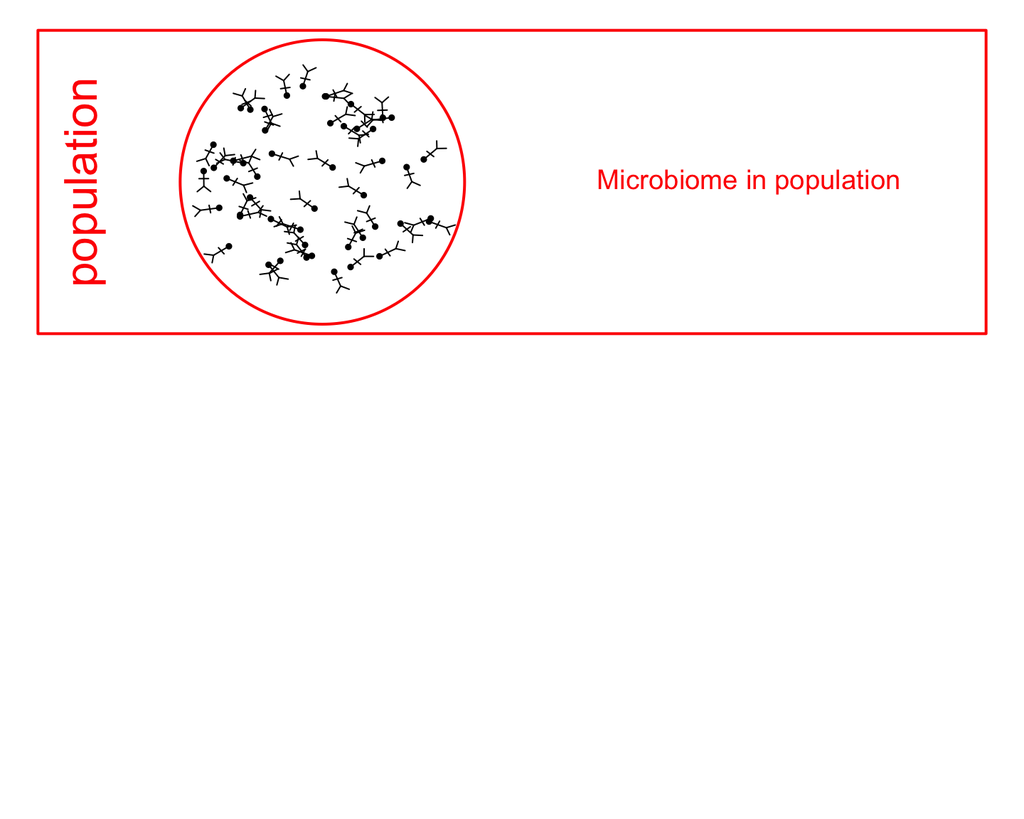

Experiment?

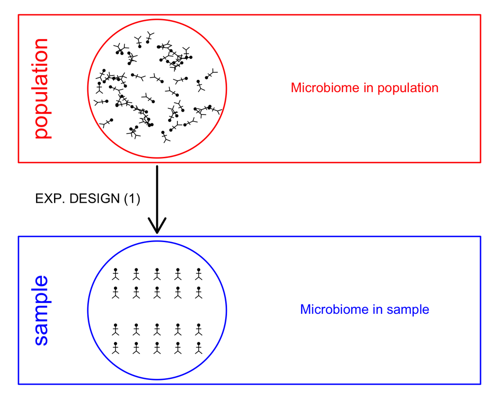

- Experiment:
  - 20 personen met okselgeur worden at random in twee behandelingsgroepen ingedeeld:
    - placebo (enkel antibiotica)
    - transplantie (antibiotica en microbiële transplantatie).
  - Het microbiome wordt bemonsterd 6 weken na de behandeling.
  - The relative abundantie van *Staphylococcus spp.* op *Corynebacterium spp.* + *Staphylococcus spp.* in het microbiome wordt gemeten via DGGE (*Denaturing Gradient Gel Electrophoresis*).

## DGGE

[figure not shown]

https://doi.org/10.1371/journal.pone.0070538

## Vertaal onderzoeksvraag in : Is er gemiddeld een verschil in relatieve abundantie van *Staphylococcus spp.* in het microbiome van de placebo en de transplantatie groep

Experiment?

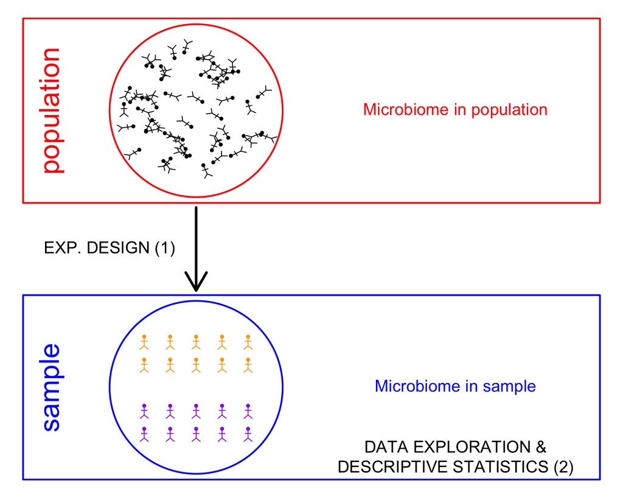

## Importeer de data

```
## # A tibble: 20 x 2
##    trt          rel
##    <chr>      <dbl>
##  1 placebo     55.0
##  2 placebo     31.8
##  3 placebo     41.1
##  4 placebo     59.5
##  5 placebo     63.6
##  6 placebo     41.5
##  7 placebo     30.4
##  8 placebo     43.0
##  9 placebo     41.7
## 10 placebo     33.9
## 11 transplant  57.2
## 12 transplant  72.5
## 13 transplant  61.9
## 14 transplant  56.7
## 15 transplant  76
## 16 transplant  71.7
## 17 transplant  57.8
## 18 transplant  65.1
## 19 transplant  67.5
## 20 transplant  77.6
```

### Beschrijvende statistiek

| trt | mean | sd |
| --- | --- | --- |
| placebo | 44.2 | 11.5 |
| transplant | 66.4 | 7.9 |

#### Barplot

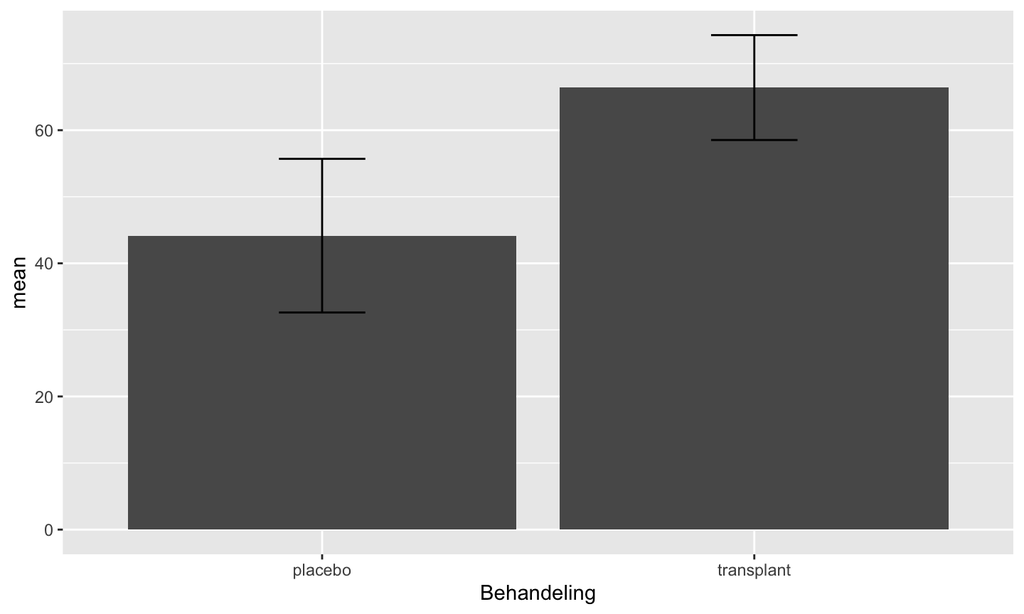

- Is deze plot informatief??

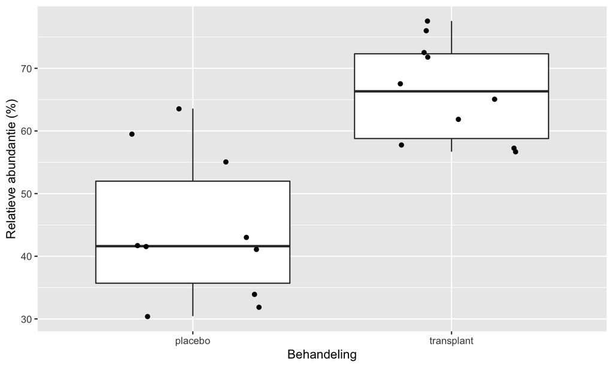

Dit is een informatieve plot!

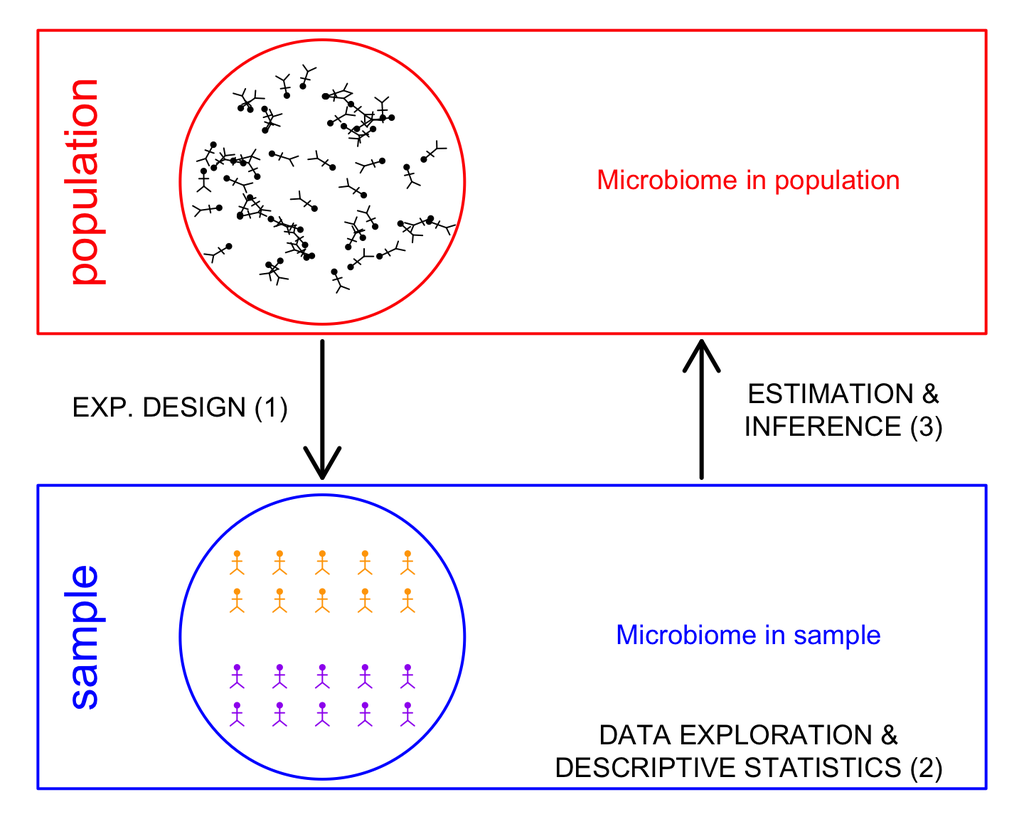

- Falsificatie principe van Popper: Data kunnen enkel een hypothese of een theorie ontkrachten.
- Met statistiek kunnen we dus niet aantonen dat de behandeling werkt.
- Statistiek zal ons wel toelaten om het omgekeerde te falsifiëren: wat is de kans om een gemiddeld verschil in relatieve abundantie te zien tussen placebo en transplantatiegroep die minstens zo groot is als in de steekproef door toeval, m.a.w. als de behandeling geen effect heeft.
- Die kans wordt een p-waarde genoemd.
- Als p heel klein is, dan is het heel onwaarschijnlijk om een dergelijk effect te observeren door toeval.
- Om deze kans te berekenen is het nodig om de data te modelleren met statistische modellen.

T-test

```r
ap %>% t.test(rel~trt,data=.)
```

```
##
##  Welch Two Sample t-test
##
## data:  rel by trt
## t = -5.0334, df = 15.892, p-value = 0.0001249
## alternative hypothesis: true difference in means is not equal to 0
## 95 percent confidence interval:
##  -31.62100 -12.87163
## sample estimates:
##    mean in group placebo mean in group transplant
##                 44.15496                 66.40127
```

Conclusie: Gemiddeld is de relatieve abundantie van Staphylococcus in het microbiome van personen met een zweetgeur 22.2% hoger na de transplantie dan na de placebo behandeling.

## Variabiliteit van steekproef tot steekproef

- Randomisatie sterk gerelateerd met het concept van de populatie en scope van de studie.
- De scope van de studie moet goed worden omschreven voor de start van het experiment.
- Om resultaten van de steekproef te kunnen veralgemenen naar de populatie toe \(\rightarrow\) trek subjecten at random uit de populatie
- Volledig random trekken van de populatie :
  - alle subjecten van de populatie hebben evenveel kans om in de steekproef te worden opgenomen.
  - selectie van een subject is onafhankelijk van andere subjecten in de steekproef.
- De steekproef is dan representatief voor de populatie, maar is nog steeds random.
- Wat betekent dit?
- Om dit te illustreren zullen we gebruik maken van een hele grote studie.
- Uit die studie zullen we herhaaldelijk kleine steekproeven trekken om te begrijpen hoe de gegevens en statistieken veranderen van steekproef tot steekproef.

```r
library(NHANES)
glimpse(NHANES)
```

```
## Observations: 10,000
## Variables: 77
## $ ID               <int> 51624, 51624, 51624, 51625, 51630, 51638, 51646…
## $ SurveyYr         <fct> 2009_10, 2009_10, 2009_10, 2009_10, 2009_10, 20…
## $ Gender           <fct> male, male, male, male, female, male, male, fem…
## $ Age              <int> 34, 34, 34, 4, 49, 9, 8, 45, 45, 45, 66, 58, 54…
## $ AgeDecade        <fct>  30-39,  30-39,  30-39,  0-9,  40-49,  0-9,  0-…
## $ AgeMonths        <int> 409, 409, 409, 49, 596, 115, 101, 541, 541, 541…
## $ Race1            <fct> White, White, White, Other, White, White, White…
## $ Race3            <fct> NA, NA, NA, NA, NA, NA, NA, NA, NA, NA, NA, NA,…
## $ Education        <fct> High School, High School, High School, NA, Some…
## $ MaritalStatus    <fct> Married, Married, Married, NA, LivePartner, NA,…
## $ HHIncome         <fct> 25000-34999, 25000-34999, 25000-34999, 20000-24…
## $ HHIncomeMid      <int> 30000, 30000, 30000, 22500, 40000, 87500, 60000…
## $ Poverty          <dbl> 1.36, 1.36, 1.36, 1.07, 1.91, 1.84, 2.33, 5.00,…
```

[output cut: 64 more lines]

Onderzoeksvraag: hoe verschilt de lengte van volwassen mannen en vrouwen.

Onderzoeksvraag: hoe verschilt de lengte van volwassen mannen en vrouwen.

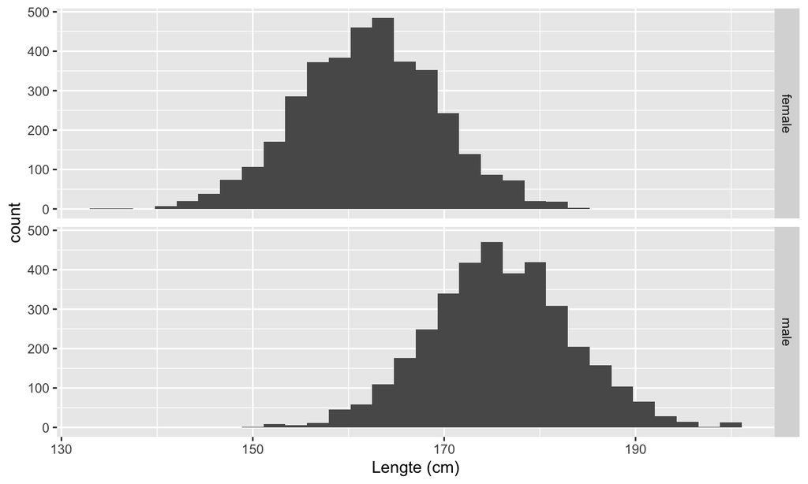

- Approximatief Normaal Verdeeld
- Normale verdeling heeft maar 2 parameters: het gemiddelde en de variantie (maat voor spreiding).
- Laat toe om de data verder samen te vatten d.m.v. twee statistieken:
  - gemiddelde
  - standaard deviatie

| Gender | mean | sd |
| --- | --- | --- |
| female | 161.9 | 7.2 |
| male | 175.8 | 7.5 |

- Stel dat we geen toegang hebben tot de metingen van de NHANES studie.
- We zouden dan een experiment op moeten zetten om metingen bij mannen en vrouwen te doen.
- Veronderstel dat we budget hebben om metingen bij 5 mannen en 5 vrouwen te doen.
- We zouden dan 5 mannen en 5 vrouwen boven de 25 jaar at random selecteren uit de Amerikaanse populatie.
- We kunnen dit experiment simuleren door 5 vrouwen en 5 mannen at random te selecteren uit de NHANES studie.

```r
samp1
```

```
## # A tibble: 10 x 2
##    Gender Height
##    <fct>   <dbl>
##  1 female   159.
##  2 female   168.
##  3 female   157.
##  4 female   155.
##  5 female   163.
##  6 male     178.
##  7 male     173.
##  8 male     187.
##  9 male     173.
## 10 male     185.
```

Data Exploratie

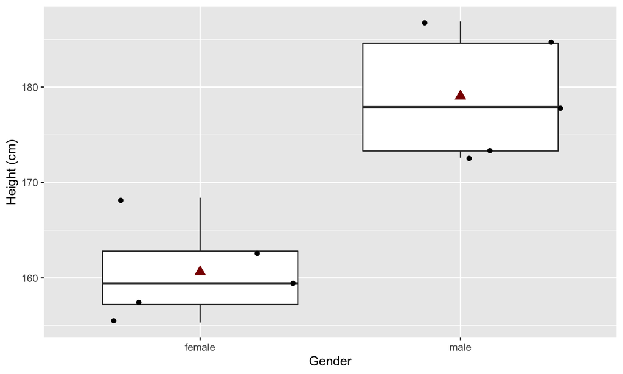

Vrouwen zijn gemiddeld 18.44 cm kleiner dan mannen. En dit verschil is statistisch significant

Herhaal experiment: Nieuwe steekproef

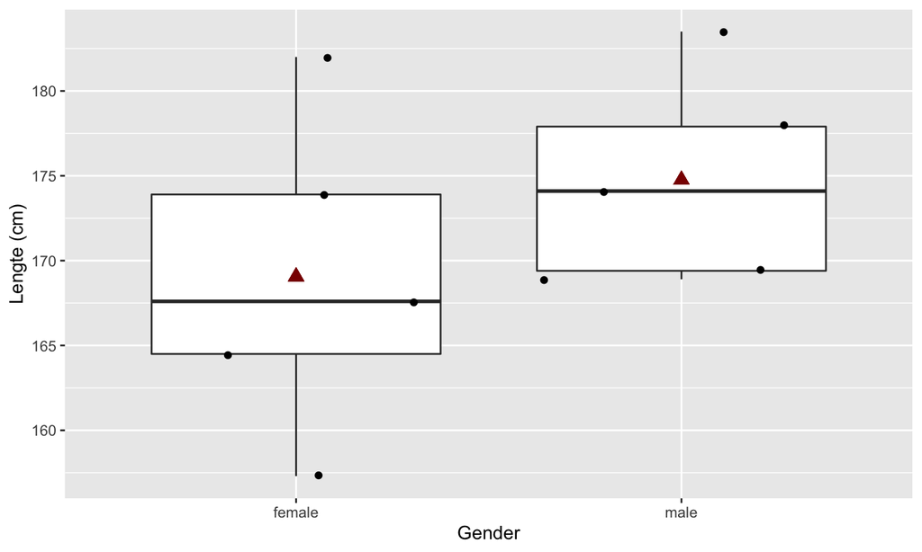

Vrouwen zijn gemiddeld 5.7 cm kleiner dan mannen. En dit verschil is statistisch niet significant

Herhaal experiment: Nieuwe steekproef

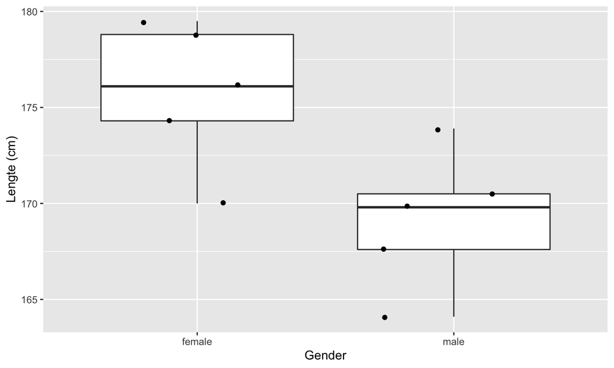

Vrouwen zijn gemiddeld 6.56 cm groter dan mannen. En dit verschil is statistisch significant

## Samenvatting

- At random andere proefpersonen in elke steekproef
- Hierdoor verschillen lengte metingen van steekproef tot steekproef.
- Dus ook het geschatte gemiddeldes en standaard deviaties.
- Ook onze conclusies zijn onzeker en kunnen wijzigen van steekproef tot steekproef.
- Steekproeven waarbij het effect tegengesteld is aan dat in de populatie en waarbij we besluiten dat het verschil significant is, zijn zeldzaam.

\(\rightarrow\) Met statistiek controleren we de kans op het trekken foute conclusies.

## We illusteren dit door repeated sampling

Op basis van 10 000 steekproeven van 5 mannen en 5 vrouwen:

- Aantal steekproeven waarvoor vrouwen gemiddeld significant kleiner zijn dan mannen: 7057
- Aantal steekproeven waarvoor vrouwen en mannen gemiddeld niet significant verschillen in lengte: 2943
- Aantal steekproeven waarvoor vrouwen gemiddeld significant groter zijn dan mannen: 0
- Ik had 1336602 steekproeven moeten trekken om de extreme steekproef te vinden waaruit we foutief zouden concluderen dat vrouwen gemiddeld significant groter zijn dan mannen.

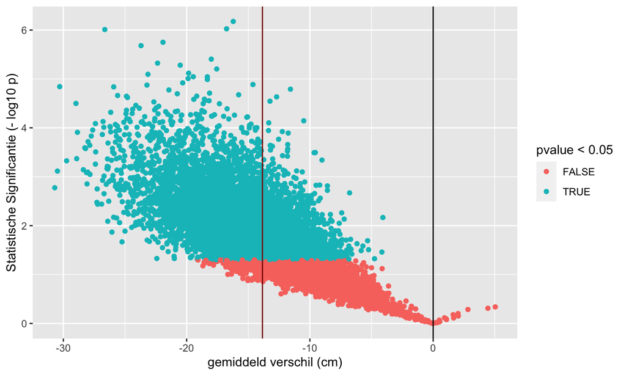

## Grotere steekproef: 50 subjecten per groep?

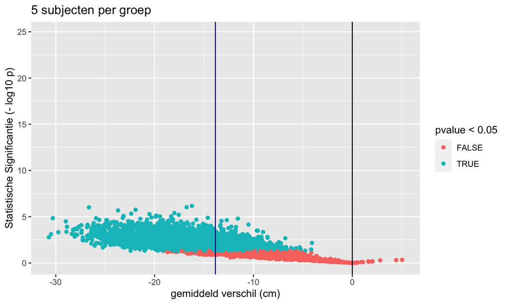

## Grotere steekproef: 50 subjecten per groep

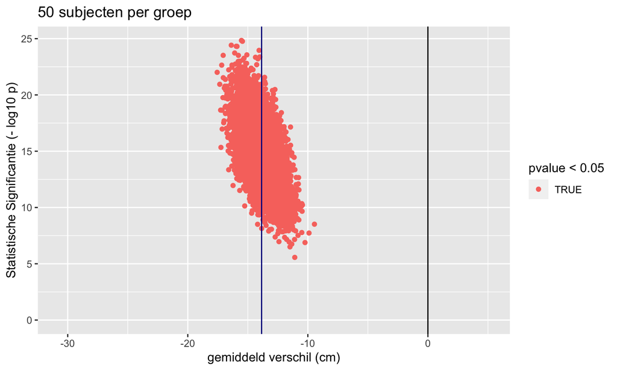

## Salk Study

- In 1916, brak de eerste grote polio epidemie uit in de USA.
- Begin de jaren 50 ontwikkelde John Salk een vaccin met belovende resultaten in het lab.
- In 1954, heeft de National Foundation for Infantile Paralysis (NFIP) een grote studie opgezet om de effectiviteit van het Salk vaccin na te gaan.
- Veronderstel dat de NFIP in 1954 een groot aantal kinderen zou hebben gevaccineerd, wat zouden ze dan kunnen besluiten als de polio incidentie in 1954 lager was dan in 1953?

## NFIP Study

### Design

- Grote simultane studie met gevaccineerde kinderen (cases) en ongevaccineerde kinderen (controles).
- In scholen van districten met hoge polio incidentie.
- Cases: kinderen van de tweede graad van het lager onderwijs waarvan de ouders toestemden met vaccinatie.
- Controles: kinderen van de eerste en derde graad.

### Data

| group | grade | vaccin | total | polio | noPolio |
| --- | --- | --- | --- | --- | --- |
| cases | g2 | yes | 221998 | 54 | 221944 |
| controls | g1g3 | no | 725173 | 391 | 724782 |
| noConcent | g2 | no | 123605 | 56 | 123549 |

Vergelijk de polio incidentie?

### Data

| group | grade | vaccin | total | polio | noPolio | incidencePM |
| --- | --- | --- | --- | --- | --- | --- |
| cases | g2 | yes | 221998 | 54 | 221944 | 243 |
| controls | g1g3 | no | 725173 | 391 | 724782 | 539 |
| noConcent | g2 | no | 123605 | 56 | 123549 | 453 |

Wat kunnen we concluderen?

## Confounding

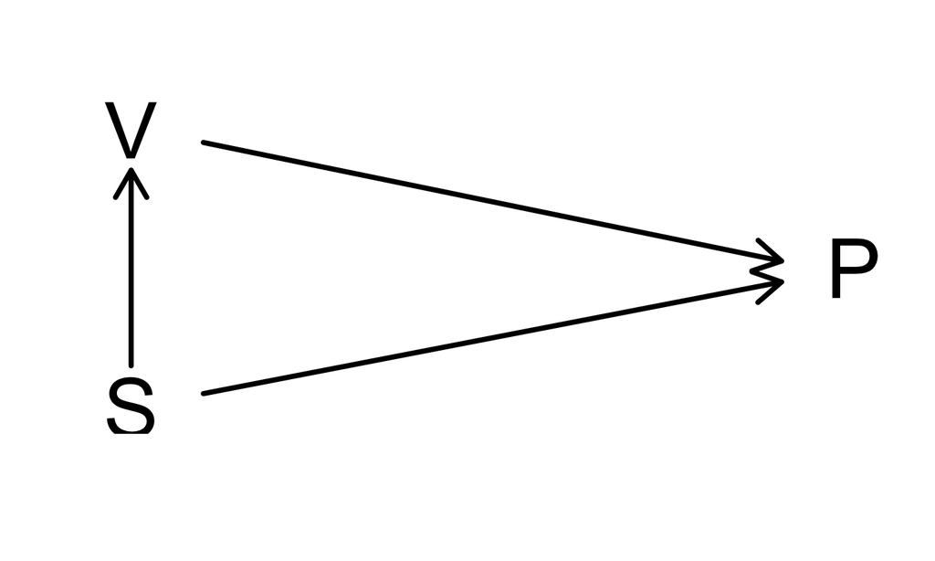

- We observeren een lagere polio (P) incidentie voor kinderen bij wie de ouders geen toestemming gaven dan in de controle groep.
- Toestemming voor vaccinatie (V) is geassocieerd met de socio-economische status (S).
- Kinderen van lagere socio-economische status zijn meer resistent tegen de ziekte.

## Confounding

- De groepen van cases en controles zijn niet vergelijkbaar
  - verschil in leeftijd
  - verschil in socio-economische status en
  - verschil in vatbaarheid voor de ziekte.

## Salk Study

### Design

Een nieuwe studie werd uitgevoerd: dubbel blinde gerandomiseerde studie.

- Kinderen worden at random toegewezen aan controle of case arm van het experiment nadat de ouders toestemden met vaccinatie.
- Controle: vaccinatie met placebo
- Treatment: vaccinatie met vaccine
- Double blinding:
  - ouders en kinderen weten niet of ze werden gevaccineerd of niet
  - medische staf en onderzoekers weten niet of het kind het vaccin of de placebo kreeg

### Data

| group | treatment | total | polio | noPolio | incidencePM |
| --- | --- | --- | --- | --- | --- |
| cases | vaccine | 200745 | 57 | 200688 | 284 |
| control | placebo | 201229 | 142 | 201087 | 706 |
| noConcent | none | 338778 | 157 | 338621 | 463 |

- We observeren een veel groter effect nu dat cases en controles vergelijkbaar zijn, incidentie van respectievelijk 284 and 706 per miljoen.
- De polio incidentie voor kinderen die geen toestemming geven blijft vergelijkbaar 453 and 463 per miljoen respectievelijk in the NFIP and Salk study.

## Rol van Statistiek

- We hebben gezien dat
  - het belangrijk is om de scope van de studie goed te specifiëren voor de start van het experiment.
  - de proefpersonen at random moeten worden getrokken uit de populatie.
  - steekproef grootte is heel belangrijk
  - we moeten ons bewust zijn van Confounding
  - een goede controle is belangrijk

\(\rightarrow\) Goede proefopzet is cruciaal!

- We hebben ook geobserveerd dat er variabiliteit is in de populatie
- We kunnen maar een steekproef nemen uit de populatie

\(\rightarrow\) onzekerheid in de resultaten

\(\rightarrow\) onzekerheid in de conclusies

- Statistiek is de wetenschap voor het
  1. verzamelen (experimenteel design),
  2. exploren (data exploration) en
  3. leren van data zodat we hetgeen we observeren in de steekproef kunnen veralgemenen naar de populatie terwijl we de onzekerheid quantificeren, controleren en rapporteren (statistisch modelleren en statistische besluitvorming).
- Statistiek speelt daarom een heel belangrijke rol in zowat alle wetenschappen